# AA_TREE

## Tree

Tree adalah struktur data non-linear yang digunakan untuk menyimpan data secara hierarkis atau bertingkat. Struktur ini menyerupai pohon terbalik, di mana terdapat satu node utama di bagian atas yang disebut root, kemudian bercabang menjadi node-node lain.

Struktur tree terdiri dari:

- Node
- Edge
- Parent
- Child
- Root
- Leaf

Contoh bentuk tree:

```
        A
      /   \
     B     C
    / \   / \
   D   E F   G
```

Konsep Dasar Tree

##### 1. Node

Node adalah elemen yang menyimpan data.

Contoh:

```
A, B, C, D
```

##### 2. Root

Root adalah node paling atas.

Contoh:

```
    A
```

##### 3. Parent dan Child

Parent adalah node induk, sedangkan child adalah node anak.

```
A
|
B
A = parent
B = child
```

##### 4. Leaf Node

Leaf node adalah node yang tidak memiliki child.

Contoh:

```
D, E, F, G
```

Implementasi Dasar Tree di Python

Membuat Node

```python
class Node:
    def __init__(self, data):
        self.data = data
        self.left = None
        self.right = None
```

Penjelasan:

- data menyimpan nilai node
- left menunjuk child kiri
- right menunjuk child kanan

Membuat Binary Tree

```python
root = Node("A")

root.left = Node("B")
root.right = Node("C")

root.left.left = Node("D")
root.left.right = Node("E")

root.right.left = Node("F")
root.right.right = Node("G")
```

Visual:

```
        A
      /   \
     B     C
    / \   / \
   D   E F   G
```

### Jenis-Jenis Tree

##### 1. General Tree

Setiap node dapat memiliki banyak child.

```
    A
  / | \
 B  C  D
```

##### 2. Binary Tree

Setiap node maksimal memiliki dua child.

```
   A
  / \
 B   C
```

Jenis Binary Tree

a. Full Binary Tree

Semua parent memiliki 0 atau 2 child.

```
        A
      /   \
     B     C
    / \   / \
   D   E F   G
```

b. Complete Binary Tree

Semua level penuh kecuali level terakhir.

```
        A
      /   \
     B     C
    / \   /
   D   E F
```

c. Skewed Tree

Semua node hanya memiliki satu child.

```
A
 \
  B
   \
    C
```

### Traversal pada Tree

Traversal adalah proses mengunjungi seluruh node pada tree.

Ada 4 traversal utama:

- Preorder
- Inorder -Postorder -Level Order

##### 1. Preorder Traversal

Urutan:

```
Root → Left → Right
```

Contoh kode:

```python
def preorder(node):
    if node:
        print(node.data, end=" ")
        preorder(node.left)
        preorder(node.right)

preorder(root)
```

```
A B D E C F G
```

##### 2. Inorder Traversal

Urutan:

```
Left → Root → Right
```

Kode:

```python
def inorder(node):
    if node:
        inorder(node.left)
        print(node.data, end=" ")
        inorder(node.right)

inorder(root)
```

```
D B E A F C G
```

##### 3. Postorder Traversal

Urutan:

```
Left → Right → Root
```

Kode:

```python
def postorder(node):
    if node:
        postorder(node.left)
        postorder(node.right)
        print(node.data, end=" ")

postorder(root)
```

```
D E B F G C A
```

##### 4. Level Order Traversal

Traversal per level menggunakan queue.

Kode:

```python
from collections import deque

def levelorder(root):
    if not root:
        return

    queue = deque([root])

    while queue:
        node = queue.popleft()
        print(node.data, end=" ")

        if node.left:
            queue.append(node.left)

        if node.right:
            queue.append(node.right)

levelorder(root)
```

```
A B C D E F G
```

### Binary Search Tree (BST)

BST adalah Binary Tree dengan aturan:

```
Nilai kiri < parent

Nilai kanan > parent
```

Contoh:

```
        50
       /  \
     30    70
    / \   / \
   20 40 60 80
```

Membuat BST di Python

```python
class BSTNode:
    def __init__(self, data):
        self.data = data
        self.left = None
        self.right = None
```

#### Insert pada BST

```python
def insert(root, data):

    if root is None:
        return BSTNode(data)

    if data < root.data:
        root.left = insert(root.left, data)

    elif data > root.data:
        root.right = insert(root.right, data)

    return root
```

#### Membuat BST

```python
root = None

data = [50, 30, 70, 20, 40, 60, 80]

for i in data:
    root = insert(root, i)
```

#### Searching pada BST

```python
def search(root, key):

    if root is None:
        return False

    if root.data == key:
        return True

    if key < root.data:
        return search(root.left, key)

    return search(root.right, key)

print(search(root, 60))
```

```
True
```

#### Delete pada BST

Penghapusan node memiliki 3 kondisi:

1. Node tanpa child
2. Node dengan satu child
3. Node dengan dua child

Contoh kode delete:

```python
def minValueNode(node):

    current = node

    while current.left is not None:
        current = current.left

    return current


def delete(root, key):

    if root is None:
        return root

    if key < root.data:
        root.left = delete(root.left, key)

    elif key > root.data:
        root.right = delete(root.right, key)

    else:

        if root.left is None:
            return root.right

        elif root.right is None:
            return root.left

        temp = minValueNode(root.right)

        root.data = temp.data

        root.right = delete(root.right, temp.data)

    return root
```

### Kompleksitas Tree

| Operasi | BST Average | BST Worst |
| --- | --- | --- |
| Search | O(log n) | O(n) |
| Insert | O(log n) | O(n) |
| Delete | O(log n) | O(n) |

Worst case terjadi jika tree tidak seimbang.

#### AVL Tree

AVL Tree adalah BST yang selalu seimbang.

Syarat AVL:

```
| tinggi kiri - tinggi kanan | ≤ 1
```

Kelebihan:

- Operasi tetap cepat
- Search lebih stabil

#### Heap Tree

Heap adalah complete binary tree.

Jenis:

- Max Heap
- Min Heap

Contoh Max Heap:

```
    100
   /   \
  50    80
```

Implementasi Heap Python

Python memiliki module heapq.

```python
import heapq

angka = [30, 10, 50, 20]

heapq.heapify(angka)

print(angka)
```

```
[10, 20, 50, 30]
```

### Trie Tree

Trie digunakan untuk:

- Dictionary
- Autocomplete
- Search kata

Contoh:

- cat
- car
- can

Struktur Trie

```
    c
    |
    a
  / | \
 t  r  n
```

### B-Tree

B-Tree digunakan pada:

- Database
- File system

Kelebihan:

- Efisien untuk data besar
- Cocok untuk penyimpanan disk
- Tree dalam Kehidupan Nyata
1. Struktur Folder

   ```
    Folder
     ├── Dokumen
     ├── Musik
     └── Video
   ```

2. Struktur Organisasi

   ```
    Direktur
     ├── Manager
     │    ├── Staff
   ```

3. HTML DOM

Struktur HTML menggunakan tree.

### Kelebihan Tree

- Struktur hierarkis
- Pencarian cepat
- Fleksibel
- Banyak digunakan di dunia nyata

### Kekurangan Tree

- Implementasi lebih sulit
- Membutuhkan pointer
- Bisa tidak seimbang

Berikut tambahan method pada class BinaryTree, untuk mendapatkan informasi mengenai left child, right child, dan root dari suatu binary tree.

```python
class BinaryTree:
    def __init__(self, root):
        self.key = root
        self.leftChild = None
        self.rightChild = None
    def insertLeft(self, new_node):
        if self.leftChild == None:
            self.leftChild = BinaryTree(new_node)
        else:
            t = BinaryTree(new_node)
            t.leftChild = self.leftChild
            self.leftChild = t
    def insertRight(self, new_node):
        if self.rightChild == None:
            self.rightChild = BinaryTree(new_node)
        else:
            t = BinaryTree(new_node)
            t.rightChild = self.rightChild
            self.rightChild = t
    def getRightChild(self):
        return self.rightChild
    def getLeftChild(self):
        return self.leftChild
    def setRootVal(self, obj):
        self.key = obj
    def getRootVal(self):
        return self.key
```

### Latihan

Buatlah binarytree dari class tersebut diatas sesuai dengan gambar berikut :

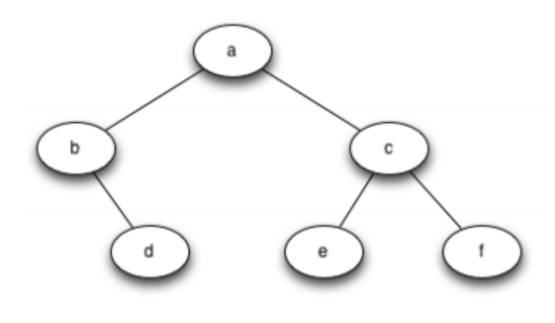

```python
class BinaryTree:
    def __init__(self, root):
        self.key = root
        self.leftChild = None
        self.rightChild = None

    def insertLeft(self, new_node):
        if self.leftChild == None:
            self.leftChild = BinaryTree(new_node)
        else:
            t = BinaryTree(new_node)
            t.leftChild = self.leftChild
            self.leftChild = t

    def insertRight(self, new_node):
        if self.rightChild == None:
            self.rightChild = BinaryTree(new_node)
        else:
            t = BinaryTree(new_node)
            t.rightChild = self.rightChild
            self.rightChild = t

    def getRightChild(self):
        return self.rightChild

    def getLeftChild(self):
        return self.leftChild

    def setRootVal(self, obj):
        self.key = obj

    def getRootVal(self):
        return self.key

tree = BinaryTree('a')

tree.insertLeft('b')
tree.insertRight('c')

tree.getLeftChild().insertLeft('d')

tree.getRightChild().insertLeft('e')
tree.getRightChild().insertRight('f')

print("Root :", tree.getRootVal())

print("Left Child dari a :", tree.getLeftChild().getRootVal())
print("Right Child dari a :", tree.getRightChild().getRootVal())

print("Child dari b :",
      tree.getLeftChild().getLeftChild().getRootVal())

print("Left Child dari c :",
      tree.getRightChild().getLeftChild().getRootVal())

print("Right Child dari c :",
      tree.getRightChild().getRightChild().getRootVal())
```

```
Root : a
Left Child dari a : b
Right Child dari a : c
Child dari b : d
Left Child dari c : e
Right Child dari c : f
```